# Data manipulation with `dplyr` II

Data Science for Biologists, Spring 2020

Poonam Shah

## Instructions

**This assignment must be submitted as an RMarkdown document on Blackboard by *Thursday February 27th at 10:00 am*.**

#### You will be graded on the following criteria:

- Did you enter your name appropriately into the YAML front matter?
- Does the document knit without errors? *Adding `eval=FALSE` to code chunks with errors will not avoid penalty.*
- Does your code in the R chunks have appropriate *comments*?
- Is your submission appropriately *professional*?
  - *You need to run SPELL CHECK before submitting*, available under `Edit->Check Spelling`, **or the ABC icon!!!!!**.
- Do all figures have clean axis labels? (Titles are optional). There should NOT be any underscores in axis labels.
- Did you write your written answers in the answer style?
- Have you addressed the questions as they are asked? Be sure to limit your code and your answers to the scope of the question!
  - If you write code that is not ultimately part of your final answer, you must either: delete it, comment it out, OR move it to a different R chunk with the added chunk options `eval=FALSE, echo=FALSE`.
- Is all work your own, including code and written answers?
  - If ANY of your submitted work is not your own (with the exception of what you have been provided), you will receive a 0 on the assignment. You will be reported for a Level 2 or 3 Academic Integrity Violation, depending on the severity of the issue.

## PREQUEL: DO NOT HARDCODE YOUR PATH TO THE DATA.

Watch in class, I will show you the way!

## Questions

For this lab/assignment, you will be using several datasets that are either built-in to R or an R package, or, is available as a CSV file in the `data/dplyr_lab2/` directory. For these, you’ll need to read in the data to use it. **Read in the CSV files for use at the BEGINNING of the question they are used for.** Once a dataset is read in, you don’t need to read it in again! Seriously, only read in a dataset once (this counts for grading!!) - otherwise you can accidentally introduce bugs, and bugs are bad. Whenever reading in a dataset, you should ALWAYS IMMEDIATELY PRINT THE DATA (tibbles only print 10 rows by default - you can just type the name of the tibble to see these). This allows readers of your reproducible and sharable document to see the data being used!

#### Question 1

Consider the two datasets named `algae_lowtide.csv` and `algae_hightide.csv`. These two datasets contain information about algal abundance measured during experiments carried out under low tide and high tide conditions, respectively. The datasets also contain information about whether there were herbivores (i.e. algae predators!) present.

Create a *single tibble* containing all information from both datasets. Your final tibble should contain three columns:

- tide (should have values “high” and “low”)
- herbivores (should have values “yes” and “no”)
- area (numeric values)

To accomplish this, you will need to manipulate the data using both `mutate()` and `bind_rows()`. Plan how you will do this first, and then implement below. *Your final tibble should be exported to a CSV simply called `algae.csv`*. In addition, if you do NOT print your final tibble, then you WILL LOSE POINTS - **you must ALWAYS LOOK AT YOUR DATA!!!**

```r
## This code chunk should read in, save, print the datasets only

#it is making a variable for algae_lowtide
low <- read_csv(paste0(path_to_data, "algae_lowtide.csv"))
#printing the variable in the knit
low
```

```
## # A tibble: 32 x 2
##    herbivores  area
##    <chr>      <dbl>
##  1 no          9.41
##  2 no         34.5
##  3 no         46.7
##  4 no         16.6
##  5 no         24.4
##  6 no         38.4
##  7 no         33.8
##  8 no         61.1
##  9 no         35.5
## 10 no         46.2
## # … with 22 more rows
```

```r
#it is making a variable for the algae_hightide
high <- read_csv(paste0(path_to_data, "algae_hightide.csv"))
#printing the variable in the knit
high
```

```
## # A tibble: 32 x 2
##    herbivores   area
##    <chr>       <dbl>
##  1 no          0.707
##  2 no         25.0
##  3 no         46.6
##  4 no          0.707
##  5 no          5.14
##  6 no          6.18
##  7 no         47.0
##  8 no         22.9
##  9 no         19.4
## 10 no         37.1
## # … with 22 more rows
```

```r
## This code chunk should perform the analysis, and export the final CSV
#dataset + pipe + mutate the low column
low %>%
  mutate(tide = "low") ->low_newtide_column
```

```
## mutate: new variable 'tide' with one unique value and 0% NA
```

```r
#showing the variable
low_newtide_column
```

```
## # A tibble: 32 x 3
##    herbivores  area tide
##    <chr>      <dbl> <chr>
##  1 no          9.41 low
##  2 no         34.5  low
##  3 no         46.7  low
##  4 no         16.6  low
##  5 no         24.4  low
##  6 no         38.4  low
##  7 no         33.8  low
##  8 no         61.1  low
##  9 no         35.5  low
## 10 no         46.2  low
## # … with 22 more rows
```

```r
#dataset + pipe + mutate the high column
high %>%
  mutate(tide = "high") ->high_newtide_column
```

```
## mutate: new variable 'tide' with one unique value and 0% NA
```

```r
#showing the variable
high_newtide_column
```

```
## # A tibble: 32 x 3
##    herbivores   area tide
##    <chr>       <dbl> <chr>
##  1 no          0.707 high
##  2 no         25.0   high
##  3 no         46.6   high
##  4 no          0.707 high
##  5 no          5.14  high
##  6 no          6.18  high
##  7 no         47.0   high
##  8 no         22.9   high
##  9 no         19.4   high
## 10 no         37.1   high
## # … with 22 more rows
```

```r
#binding the rows for the to dataset -> into a new dataset
bind_rows(low_newtide_column, high_newtide_column) -> algae_full

#writing in the csv
write_csv(algae_full, "algae.cvs")
```

#### Question 2

Consider the two datasets named `mammals_diet.csv` and `mammals_info.csv`. These two datasets contain information about several different, including their diet, adult average body weight in kg, and the average amount of hours they sleep per night. Read in these two data sets, and then combine them (using the SAME ORDER of arguments each time!) with each of the functions `left_join()`, `right_join()`, `inner_join()`, and finally `anti_join()`. Examine and visually compare their outputs to understand the differences among these functions. Explain *using a markdown bulleted list* the differences among these functions in the space below (short explanations please!). PS: Don’t plagiarize from the documentation. That’s an IAV.

```r
## This code chunk should read in, save, print the datasets only

#reading in the mammals diet data
mammals_diet <- read_csv(paste0(path_to_data, "mammals_diet.csv"))
#the saved variable
mammals_diet
```

```
## # A tibble: 4 x 3
##   name                           order        diet
##   <chr>                          <chr>        <chr>
## 1 Patas monkey                   Primates     omnivore
## 2 Thirteen-lined ground squirrel Rodentia     herbivore
## 3 Lesser short-tailed shrew      Soricomorpha omnivore
## 4 Baboon                         Primates     omnivore
```

```r
#reading in the mammls info data
mammals_info <- read_csv(paste0(path_to_data, "mammals_info.csv"))
#Saved variable
mammals_info
```

```
## # A tibble: 4 x 4
##   name                           order     sleep_hours bodywt_kg
##   <chr>                          <chr>           <dbl>     <dbl>
## 1 Patas monkey                   Primates         10.9    10
## 2 Thirteen-lined ground squirrel Rodentia         13.8     0.101
## 3 Domestic cat                   Carnivora        12.5     3.3
## 4 Baboon                         Primates          9.4    25.2
```

```r
## perform joins here, and print the output to compare!

#left join on the two mammals data
left_join(mammals_diet, mammals_info)
```

```
##            > rows only in x   1
##            > rows only in y  (1)
##            > matched rows     3
##            >                 ===
##            > rows total       4
```

```
## # A tibble: 4 x 5
##   name                           order        diet      sleep_hours bodywt_kg
##   <chr>                          <chr>        <chr>           <dbl>     <dbl>
## 1 Patas monkey                   Primates     omnivore         10.9    10
## 2 Thirteen-lined ground squirrel Rodentia     herbivore        13.8     0.101
## 3 Lesser short-tailed shrew      Soricomorpha omnivore         NA      NA
## 4 Baboon                         Primates     omnivore          9.4    25.2
```

```r
#right join on the two mammals data
right_join(mammals_diet, mammals_info)
```

```
##             > rows only in x  (1)
##             > rows only in y   1
##             > matched rows     3
##             >                 ===
##             > rows total       4
```

```
## # A tibble: 4 x 5
##   name                           order     diet      sleep_hours bodywt_kg
##   <chr>                          <chr>     <chr>           <dbl>     <dbl>
## 1 Patas monkey                   Primates  omnivore         10.9    10
## 2 Thirteen-lined ground squirrel Rodentia  herbivore        13.8     0.101
## 3 Domestic cat                   Carnivora <NA>             12.5     3.3
## 4 Baboon                         Primates  omnivore          9.4    25.2
```

```r
#inner join on the two mammals data
inner_join(mammals_diet, mammals_info)
```

```
##             > rows only in x  (1)
##             > rows only in y  (1)
##             > matched rows     3
##             >                 ===
##             > rows total       3
```

```
## # A tibble: 3 x 5
##   name                           order    diet      sleep_hours bodywt_kg
##   <chr>                          <chr>    <chr>           <dbl>     <dbl>
## 1 Patas monkey                   Primates omnivore         10.9    10
## 2 Thirteen-lined ground squirrel Rodentia herbivore        13.8     0.101
## 3 Baboon                         Primates omnivore          9.4    25.2
```

```r
#anti join on the two mammals data
anti_join(mammals_diet, mammals_info)
```

```
##            > rows only in x   1
##            > rows only in y  (1)
##            > matched rows    (3)
##            >                 ===
##            > rows total       1
```

```
## # A tibble: 1 x 3
##   name                      order        diet
##   <chr>                     <chr>        <chr>
## 1 Lesser short-tailed shrew Soricomorpha omnivore
```

left join will read everything to the left to the right. It will miss the data in the sleep and body.

right join will read everything to the right to the left. It will miss the data in column diet

The inner join looks at all the columns in the middle. Now there is no missing data

#### Question 3

Now, consider the additional dataset named `diets_foods.csv` which gives some example foods that different “vores” might eat. Combine this dataset with the previous other two mammal datasets to *create the largest table possible (i.e. with the most number of mammals) that DOES NOT contain NAs.* There may be multiple versions of this solution (in terms of table w/ most number of rows), but only give one. Your final output must be ordered based ascending body weights.

```r
## This code chunk should read in, save, print the dataset only

#reading in the diets food data
diets_food <- read_csv(paste0(path_to_data, "diets_foods.csv"))
#the saved variable
diets_food
```

```
## # A tibble: 3 x 2
##   diet      food
##   <chr>     <chr>
## 1 carnivore meat
## 2 herbivore leaves
## 3 omnivore  all_the_noms
```

```r
## perform tasks here
#mammals_diet, mammals_info, diets_food and inner join

#Join the similar columns for the mammals_diet and diets_food. Saved as a new variable
inner_join(mammals_diet, diets_food) -> full_diet_mammals
```

```
##             > rows only in x  (0)
##             > rows only in y  (1)
##             > matched rows     4
##             >                 ===
##             > rows total       4
```

```r
#showing the results of the full_diet_mammals
full_diet_mammals
```

```
## # A tibble: 4 x 4
##   name                           order        diet      food
##   <chr>                          <chr>        <chr>     <chr>
## 1 Patas monkey                   Primates     omnivore  all_the_noms
## 2 Thirteen-lined ground squirrel Rodentia     herbivore leaves
## 3 Lesser short-tailed shrew      Soricomorpha omnivore  all_the_noms
## 4 Baboon                         Primates     omnivore  all_the_noms
```

```r
#binding the columns of the mammals_info and full_diet_mammals. Saved as a new variable as largest_mammal_data
bind_cols(mammals_info, full_diet_mammals) -> largest_mammal_data

#showing the variable
largest_mammal_data
```

```
## # A tibble: 4 x 8
##   name          order   sleep_hours bodywt_kg name1        order1  diet   food
##   <chr>         <chr>         <dbl>     <dbl> <chr>        <chr>   <chr>  <chr>
## 1 Patas monkey  Primat…        10.9    10     Patas monkey Primat… omniv… all_t…
## 2 Thirteen-lin… Rodent…        13.8     0.101 Thirteen-li… Rodent… herbi… leaves
## 3 Domestic cat  Carniv…        12.5     3.3   Lesser shor… Sorico… omniv… all_t…
## 4 Baboon        Primat…         9.4    25.2   Baboon       Primat… omniv… all_t…
```

```r
#variable being piped to deleted the extra name and order columns
largest_mammal_data %>%
  select(-name1,-order1) %>%
  #piped into the arrange function to ascending by the bobywt_kg
  arrange(bodywt_kg)
```

```
## select: dropped 2 variables (name1, order1)
```

```
## # A tibble: 4 x 6
##   name                       order     sleep_hours bodywt_kg diet     food
##   <chr>                      <chr>           <dbl>     <dbl> <chr>    <chr>
## 1 Thirteen-lined ground squ… Rodentia         13.8     0.101 herbivo… leaves
## 2 Domestic cat               Carnivora        12.5     3.3   omnivore all_the_n…
## 3 Patas monkey               Primates         10.9    10     omnivore all_the_n…
## 4 Baboon                     Primates          9.4    25.2   omnivore all_the_n…
```

#### Question 4

This question will consider the `ggplot2` dataset (it’s built-in to the library and loaded already!) called `msleep` which, you guessed it, is what I used to make questions 2-3. This dataset contains many missing values. Examine the dataset visually with `View()` from the console to get a full sense. We’ll use this dataset to practice working with missing data in a variety of ways.

- Create **four** new versions of this data, each one saved to a new variable of its own *with a meaningful name*! The new versions should be as follows (each is independent; don’t “build” instructions on top of each other). Be sure to use `dplyr` command(s)!!
  1. All rows with NA are removed, using `drop_na()`.
  2. All rows with NA in the `conservation` column ONLY are removed, using `drop_na()`. The result will still have NA’s, just not in this column.
  3. All rows with NA in the `brainwt` column ONLY are removed, using `drop_na()`. The result will still have NA’s, just not in this column.
  4. All NAs in the column `brainwt` are replaced with the number 0, using `replace_na()`. (But think: should you ever actually do this in real data analysis? ..NO.)

Be sure to print the output for each new version!

```r
## define the FOUR new data frames here

#msleep is a build in data set
head(msleep)
```

```
## # A tibble: 6 x 11
##   name  genus vore  order conservation sleep_total sleep_rem sleep_cycle awake
##   <chr> <chr> <chr> <chr> <chr>              <dbl>     <dbl>       <dbl> <dbl>
## 1 Chee… Acin… carni Carn… lc                  12.1      NA        NA      11.9
## 2 Owl … Aotus omni  Prim… <NA>                17         1.8      NA       7
## 3 Moun… Aplo… herbi Rode… nt                  14.4       2.4      NA       9.6
## 4 Grea… Blar… omni  Sori… lc                  14.9       2.3       0.133   9.1
## 5 Cow   Bos   herbi Arti… domesticated         4         0.7       0.667  20
## 6 Thre… Brad… herbi Pilo… <NA>                14.4       2.2       0.767   9.6
## # … with 2 more variables: brainwt <dbl>, bodywt <dbl>
```

```r
#1.All rows with NA are removed, using drop_na()
#drop the missing data in msleep
drop_na(msleep)->No_na_msleep
```

```
## drop_na: removed 63 rows (76%), 20 rows remaining
```

```r
#showing the results
No_na_msleep
```

```
## # A tibble: 20 x 11
##    name  genus vore  order conservation sleep_total sleep_rem sleep_cycle awake
##    <chr> <chr> <chr> <chr> <chr>              <dbl>     <dbl>       <dbl> <dbl>
##  1 Grea… Blar… omni  Sori… lc                  14.9       2.3       0.133   9.1
##  2 Cow   Bos   herbi Arti… domesticated         4         0.7       0.667  20
##  3 Dog   Canis carni Carn… domesticated        10.1       2.9       0.333  13.9
##  4 Guin… Cavis herbi Rode… domesticated         9.4       0.8       0.217  14.6
##  5 Chin… Chin… herbi Rode… domesticated        12.5       1.5       0.117  11.5
##  6 Less… Cryp… omni  Sori… lc                   9.1       1.4       0.15   14.9
##  7 Long… Dasy… carni Cing… lc                  17.4       3.1       0.383   6.6
##  8 Nort… Dide… omni  Dide… lc                  18         4.9       0.333   6
##  9 Big … Epte… inse… Chir… lc                  19.7       3.9       0.117   4.3
## 10 Horse Equus herbi Peri… domesticated         2.9       0.6       1      21.1
## 11 Euro… Erin… omni  Erin… lc                  10.1       3.5       0.283  13.9
## 12 Dome… Felis carni Carn… domesticated        12.5       3.2       0.417  11.5
## 13 Gold… Meso… herbi Rode… en                  14.3       3.1       0.2     9.7
## 14 Hous… Mus   herbi Rode… nt                  12.5       1.4       0.183  11.5
## 15 Rabb… Oryc… herbi Lago… domesticated         8.4       0.9       0.417  15.6
## 16 Labo… Ratt… herbi Rode… lc                  13         2.4       0.183  11
## 17 East… Scal… inse… Sori… lc                   8.4       2.1       0.167  15.6
## 18 Thir… Sper… herbi Rode… lc                  13.8       3.4       0.217  10.2
## 19 Pig   Sus   omni  Arti… domesticated         9.1       2.4       0.5    14.9
## 20 Braz… Tapi… herbi Peri… vu                   4.4       1         0.9    19.6
## # … with 2 more variables: brainwt <dbl>, bodywt <dbl>
```

```r
#2.All rows with NA in the conservation column ONLY are removed, using drop_na(). The result will still have NA’s, just not in this column.
#the data set piped into the drop_na function
msleep %>%
  #deleting the missing data in the conservation column
  drop_na(conservation) -> No_na_conservation
```

```
## drop_na: removed 29 rows (35%), 54 rows remaining
```

```r
#showing the results
No_na_conservation
```

```
## # A tibble: 54 x 11
##    name  genus vore  order conservation sleep_total sleep_rem sleep_cycle awake
##    <chr> <chr> <chr> <chr> <chr>              <dbl>     <dbl>       <dbl> <dbl>
##  1 Chee… Acin… carni Carn… lc                  12.1      NA        NA      11.9
##  2 Moun… Aplo… herbi Rode… nt                  14.4       2.4      NA       9.6
##  3 Grea… Blar… omni  Sori… lc                  14.9       2.3       0.133   9.1
##  4 Cow   Bos   herbi Arti… domesticated         4         0.7       0.667  20
##  5 Nort… Call… carni Carn… vu                   8.7       1.4       0.383  15.3
##  6 Dog   Canis carni Carn… domesticated        10.1       2.9       0.333  13.9
##  7 Roe … Capr… herbi Arti… lc                   3        NA        NA      21
##  8 Goat  Capri herbi Arti… lc                   5.3       0.6      NA      18.7
##  9 Guin… Cavis herbi Rode… domesticated         9.4       0.8       0.217  14.6
## 10 Griv… Cerc… omni  Prim… lc                  10         0.7      NA      14
## # … with 44 more rows, and 2 more variables: brainwt <dbl>, bodywt <dbl>
```

```r
#3. All rows with NA in the brainwt column ONLY are removed, using drop_na(). The result will still have NA’s, just not in this column.
#dataset piped into the drop_na function
msleep %>%
  #deleting the missing data in the brainwt column
  drop_na(brainwt) -> No_na_brainwt
```

```
## drop_na: removed 27 rows (33%), 56 rows remaining
```

```r
#showing the results
No_na_brainwt
```

```
## # A tibble: 56 x 11
##    name  genus vore  order conservation sleep_total sleep_rem sleep_cycle awake
##    <chr> <chr> <chr> <chr> <chr>              <dbl>     <dbl>       <dbl> <dbl>
##  1 Owl … Aotus omni  Prim… <NA>                17         1.8      NA       7
##  2 Grea… Blar… omni  Sori… lc                  14.9       2.3       0.133   9.1
##  3 Cow   Bos   herbi Arti… domesticated         4         0.7       0.667  20
##  4 Dog   Canis carni Carn… domesticated        10.1       2.9       0.333  13.9
##  5 Roe … Capr… herbi Arti… lc                   3        NA        NA      21
##  6 Goat  Capri herbi Arti… lc                   5.3       0.6      NA      18.7
##  7 Guin… Cavis herbi Rode… domesticated         9.4       0.8       0.217  14.6
##  8 Chin… Chin… herbi Rode… domesticated        12.5       1.5       0.117  11.5
##  9 Star… Cond… omni  Sori… lc                  10.3       2.2      NA      13.7
## 10 Afri… Cric… omni  Rode… <NA>                 8.3       2        NA      15.7
## # … with 46 more rows, and 2 more variables: brainwt <dbl>, bodywt <dbl>
```

```r
#4.All NAs in the column brainwt are replaced with the number 0, using replace_na(). (But think: should you ever actually do this in real data analysis? ..NO.)
#pipping in the dataset
msleep %>%
  #the Na are replaced with 0 in the brainwt column
  replace_na(list(brainwt= 0)) -> replace_na_0_brainwt
```

```
## replace_na: changed 27 values (33%) of 'brainwt' (27 fewer NA)
```

```r
#showing the results
replace_na_0_brainwt
```

```
## # A tibble: 83 x 11
##    name  genus vore  order conservation sleep_total sleep_rem sleep_cycle awake
##    <chr> <chr> <chr> <chr> <chr>              <dbl>     <dbl>       <dbl> <dbl>
##  1 Chee… Acin… carni Carn… lc                  12.1      NA        NA      11.9
##  2 Owl … Aotus omni  Prim… <NA>                17         1.8      NA       7
##  3 Moun… Aplo… herbi Rode… nt                  14.4       2.4      NA       9.6
##  4 Grea… Blar… omni  Sori… lc                  14.9       2.3       0.133   9.1
##  5 Cow   Bos   herbi Arti… domesticated         4         0.7       0.667  20
##  6 Thre… Brad… herbi Pilo… <NA>                14.4       2.2       0.767   9.6
##  7 Nort… Call… carni Carn… vu                   8.7       1.4       0.383  15.3
##  8 Vesp… Calo… <NA>  Rode… <NA>                 7        NA        NA      17
##  9 Dog   Canis carni Carn… domesticated        10.1       2.9       0.333  13.9
## 10 Roe … Capr… herbi Arti… lc                   3        NA        NA      21
## # … with 73 more rows, and 2 more variables: brainwt <dbl>, bodywt <dbl>
```

Then, for each version AND the original untouched `msleep`, calculate the mean brain weight (`brainwt` - NOT BODY WEIGHT!) using simply `mean(dataframe$column-with-weight)`. For the original untouched version, calculate the mean TWICE: once as usual, and once with the added argument `na.rm=TRUE` provided to `mean()`.

```r
## calculate the SIX means here (read directions to know what this means - one for each new dataset, and two for the original)
#the usual mean
mean(msleep$brainwt)
```

```
## [1] NA
```

```r
#the added arguement of na.rm=true
mean(msleep$brainwt, na.rm = TRUE)
```

```
## [1] 0.2815814
```

**Compare your outputs** - are they all the same? Which one(s) is(are) correct? Below, explain briefly which one(s) give(s) the right answer, and why the wrong ones are wrong. **This can/should be a bulleted list.**

They are not the same. The usual way to do the mean is showing up as empty. The usual with the added arugement had an answer of 0.282. The correct answer is mean(msleep$brainwt, na.rm = TRUE). mean(msleep$brainwt) is the wrong answer because of the NA answer

#### Question 5

For this question, we’ll work with conditional mutation using the dataset `pima.csv`, which contains information about Pima Native women in the North American southwest who, as a population, tend to have elevated rates of Type II Diabetes.

```r
## read in, save, print dataset here
pima <- read_csv(paste0(path_to_data, "pima.csv"))
#show the variable
pima
```

```
## # A tibble: 752 x 9
##    npreg glucose   dbp  skin insulin   bmi pedigree   age diabetic
##    <dbl>   <dbl> <dbl> <dbl>   <dbl> <dbl>    <dbl> <dbl> <chr>
##  1     6     148    72    35       0  33.6    0.627    50 Yes
##  2     1      85    66    29       0  26.6    0.351    31 No
##  3     8     183    64     0       0  23.3    0.672    32 Yes
##  4     1      89    66    23      94  28.1    0.167    21 No
##  5     0     137    40    35     168  43.1    2.29     33 Yes
##  6     5     116    74     0       0  25.6    0.201    30 No
##  7     3      78    50    32      88  31      0.248    26 Yes
##  8    10     115     0     0       0  35.3    0.134    29 No
##  9     2     197    70    45     543  30.5    0.158    53 Yes
## 10     4     110    92     0       0  37.6    0.191    30 No
## # … with 742 more rows
```

- Create a new column called `glucose_status` using the functions `mutate()` and `case_when()` that recodes `glucose` into levels “low” (<= 70), “average” (>70, <=120), “above-average” (>120, <=160), and “high” (>160). Save your result to a new variable and print the output to confirm. **HINT!!** You may need to refer back to the intro lab to remind yourself about `&`.

```r
# wrangle
#pipped the data
pima %>%
  #Used mutate to added the glucose status. Use cae_when for multiply variables
  mutate(glucose_status= case_when(glucose <= 70 ~ "low",
                                   glucose >70 & glucose <=120 ~ "average",
                                   glucose >120 & glucose <=160 ~"above-average",
                                   glucose >160 ~"high")) -> new_column_glucose_status #new Variable
```

```
## mutate: new variable 'glucose_status' with 4 unique values and 0% NA
```

```r
#show the variable
new_column_glucose_status
```

```
## # A tibble: 752 x 10
##    npreg glucose   dbp  skin insulin   bmi pedigree   age diabetic
##    <dbl>   <dbl> <dbl> <dbl>   <dbl> <dbl>    <dbl> <dbl> <chr>
##  1     6     148    72    35       0  33.6    0.627    50 Yes
##  2     1      85    66    29       0  26.6    0.351    31 No
##  3     8     183    64     0       0  23.3    0.672    32 Yes
##  4     1      89    66    23      94  28.1    0.167    21 No
##  5     0     137    40    35     168  43.1    2.29     33 Yes
##  6     5     116    74     0       0  25.6    0.201    30 No
##  7     3      78    50    32      88  31      0.248    26 Yes
##  8    10     115     0     0       0  35.3    0.134    29 No
##  9     2     197    70    45     543  30.5    0.158    53 Yes
## 10     4     110    92     0       0  37.6    0.191    30 No
## # … with 742 more rows, and 1 more variable: glucose_status <chr>
```

- Visualize the relationship between your new column `glucose_status` and `diabetic`. Hint: how can we see TWO categorical variables in one plot? You’ve done this before! It’s a barplot! **Make sure it is DODGED** and not stacked. **Importantly** when you first make this plot it will likely have undesirable visual features. To fix this, read over [this documentation](https://ggplot2.tidyverse.org/reference/position_dodge.html) and find the solution to implement here (2nd plot from the top).

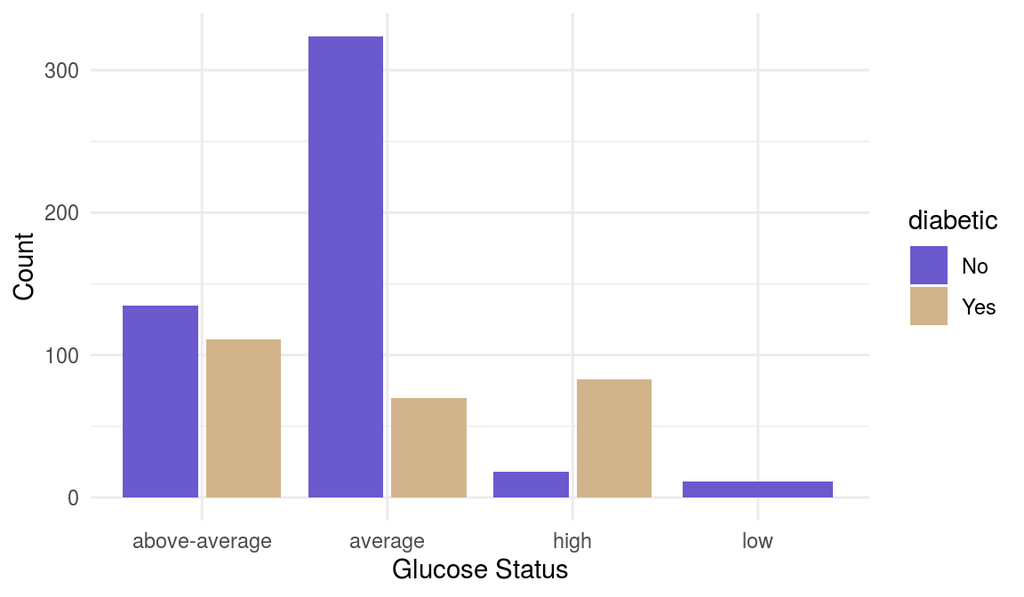

```r
#piped in the dataset
new_column_glucose_status %>%

  #ggplot +aes+ x axis on the glucose status + being filled with diaetic data
  ggplot(aes(x=glucose_status, fill=diabetic)) +

  #it is going to be a bar plot with changes in the space between the bars
  geom_bar(position = "dodge2") +

  #clearing up the axis
  labs(x="Glucose Status", y="Count") +

  #changed the colors
  scale_fill_manual(values = c(color_choice_1,color_choice_2))
```

- Use `if_else()` and `mutate()` to create a new column called “pregnant” to say “Yes” if the individual ever was pregant, and “No” if the individual never had a pregnancy. Save the output for subsequent use.

```r
#ifelse
#data set + pipe factor
pima %>%
  #making a new column from the pregnant column
  mutate(pregnant= if_else(npreg > 0, "Yes", "No")) -> new_column_pregnant
```

```
## mutate: new variable 'pregnant' with 2 unique values and 0% NA
```

```r
#showing the vaule
new_column_pregnant
```

```
## # A tibble: 752 x 10
##    npreg glucose   dbp  skin insulin   bmi pedigree   age diabetic pregnant
##    <dbl>   <dbl> <dbl> <dbl>   <dbl> <dbl>    <dbl> <dbl> <chr>    <chr>
##  1     6     148    72    35       0  33.6    0.627    50 Yes      Yes
##  2     1      85    66    29       0  26.6    0.351    31 No       Yes
##  3     8     183    64     0       0  23.3    0.672    32 Yes      Yes
##  4     1      89    66    23      94  28.1    0.167    21 No       Yes
##  5     0     137    40    35     168  43.1    2.29     33 Yes      No
##  6     5     116    74     0       0  25.6    0.201    30 No       Yes
##  7     3      78    50    32      88  31      0.248    26 Yes      Yes
##  8    10     115     0     0       0  35.3    0.134    29 No       Yes
##  9     2     197    70    45     543  30.5    0.158    53 Yes      Yes
## 10     4     110    92     0       0  37.6    0.191    30 No       Yes
## # … with 742 more rows
```

- Check that your new pregnant variable is correct by wrting code to reveal: Is the sum of npreg for all rows where pregnant is “No” 0? If this is true, it worked! This can be done entirely with `dplyr` commands. This is how one might write an assertion - ask if this condition is true, and if not, the script should die. For an added challenge, actually write an assertion in the code chunk (to this end, check out the function `dplyr::pull()`. Super useful.)

```r
#data set + piped
pima %>%
  #adding a new column, using the if else to make a Yes and no in the column
  mutate(pregnant= if_else(npreg > 0, "Yes", "No")) %>%
  #pull the data from pregnent column
  pull(pregnant)
```

```
## mutate: new variable 'pregnant' with 2 unique values and 0% NA
```

```
##   [1] "Yes" "Yes" "Yes" "Yes" "No"  "Yes" "Yes" "Yes" "Yes" "Yes" "Yes" "Yes"
##  [13] "Yes" "Yes" "Yes" "No"  "Yes" "Yes" "Yes" "Yes" "Yes" "Yes" "Yes" "Yes"
##  [25] "Yes" "Yes" "Yes" "Yes" "Yes" "Yes" "Yes" "Yes" "Yes" "Yes" "Yes" "Yes"
##  [37] "Yes" "Yes" "Yes" "Yes" "Yes" "Yes" "Yes" "Yes" "No"  "Yes" "Yes" "Yes"
##  [49] "Yes" "Yes" "Yes" "Yes" "Yes" "Yes" "Yes" "No"  "No"  "No"  "Yes" "Yes"
##  [61] "Yes" "Yes" "Yes" "No"  "Yes" "Yes" "Yes" "Yes" "Yes" "Yes" "Yes" "Yes"
##  [73] "Yes" "Yes" "No"  "Yes" "Yes" "Yes" "No"  "Yes" "Yes" "Yes" "Yes" "Yes"
##  [85] "Yes" "Yes" "Yes" "Yes" "Yes" "Yes" "Yes" "Yes" "Yes" "Yes" "Yes" "Yes"
##  [97] "Yes" "No"  "Yes" "Yes" "Yes" "Yes" "Yes" "Yes" "No"  "Yes" "Yes" "Yes"
## [109] "Yes" "Yes" "Yes" "Yes" "Yes" "Yes" "Yes" "No"  "Yes" "Yes" "Yes" "No"
## [121] "Yes" "Yes" "Yes" "Yes" "No"  "Yes" "Yes" "Yes" "Yes" "Yes" "Yes" "No"
## [133] "No"  "No"  "Yes" "Yes" "Yes" "Yes" "Yes" "Yes" "Yes" "Yes" "Yes" "Yes"
## [145] "Yes" "Yes" "Yes" "Yes" "Yes" "Yes" "Yes" "Yes" "Yes" "Yes" "Yes" "Yes"
## [157] "No"  "Yes" "No"  "Yes" "Yes" "Yes" "Yes" "Yes" "Yes" "Yes" "Yes" "Yes"
## [169] "Yes" "Yes" "Yes" "No"  "Yes" "Yes" "Yes" "No"  "Yes" "Yes" "Yes" "Yes"
```

[output cut: 48 more lines]

```r
#pull the data from new column pregnant
pull(new_column_pregnant)
```

```
##   [1] "Yes" "Yes" "Yes" "Yes" "No"  "Yes" "Yes" "Yes" "Yes" "Yes" "Yes" "Yes"
##  [13] "Yes" "Yes" "Yes" "No"  "Yes" "Yes" "Yes" "Yes" "Yes" "Yes" "Yes" "Yes"
##  [25] "Yes" "Yes" "Yes" "Yes" "Yes" "Yes" "Yes" "Yes" "Yes" "Yes" "Yes" "Yes"
##  [37] "Yes" "Yes" "Yes" "Yes" "Yes" "Yes" "Yes" "Yes" "No"  "Yes" "Yes" "Yes"
##  [49] "Yes" "Yes" "Yes" "Yes" "Yes" "Yes" "Yes" "No"  "No"  "No"  "Yes" "Yes"
##  [61] "Yes" "Yes" "Yes" "No"  "Yes" "Yes" "Yes" "Yes" "Yes" "Yes" "Yes" "Yes"
##  [73] "Yes" "Yes" "No"  "Yes" "Yes" "Yes" "No"  "Yes" "Yes" "Yes" "Yes" "Yes"
##  [85] "Yes" "Yes" "Yes" "Yes" "Yes" "Yes" "Yes" "Yes" "Yes" "Yes" "Yes" "Yes"
##  [97] "Yes" "No"  "Yes" "Yes" "Yes" "Yes" "Yes" "Yes" "No"  "Yes" "Yes" "Yes"
## [109] "Yes" "Yes" "Yes" "Yes" "Yes" "Yes" "Yes" "No"  "Yes" "Yes" "Yes" "No"
## [121] "Yes" "Yes" "Yes" "Yes" "No"  "Yes" "Yes" "Yes" "Yes" "Yes" "Yes" "No"
## [133] "No"  "No"  "Yes" "Yes" "Yes" "Yes" "Yes" "Yes" "Yes" "Yes" "Yes" "Yes"
## [145] "Yes" "Yes" "Yes" "Yes" "Yes" "Yes" "Yes" "Yes" "Yes" "Yes" "Yes" "Yes"
## [157] "No"  "Yes" "No"  "Yes" "Yes" "Yes" "Yes" "Yes" "Yes" "Yes" "Yes" "Yes"
## [169] "Yes" "Yes" "Yes" "No"  "Yes" "Yes" "Yes" "No"  "Yes" "Yes" "Yes" "Yes"
```

[output cut: 48 more lines]

- From the original dataset, *replace* the column `diabetic` with a new version that says `TRUE` and `FALSE` instead of Yes and No. Do this in two ways: with `if_else()` and with `case_when()`. Be careful not to actually overwrite the original version of the data itself!!

```r
# solution with if_else
pima %>%
  #new column Diabetics to read the yes as true and no as false
  mutate(Diabetics = if_else(diabetic == "Yes", TRUE, FALSE)) %>%

  #delected the orginal diabetic column, + a new data set
  select(-diabetic)-> new_pima_part_5.6
```

```
## mutate: new variable 'Diabetics' with 2 unique values and 0% NA
```

```
## select: dropped one variable (diabetic)
```

```r
#Show the variable
new_pima_part_5.6
```

```
## # A tibble: 752 x 9
##    npreg glucose   dbp  skin insulin   bmi pedigree   age Diabetics
##    <dbl>   <dbl> <dbl> <dbl>   <dbl> <dbl>    <dbl> <dbl> <lgl>
##  1     6     148    72    35       0  33.6    0.627    50 TRUE
##  2     1      85    66    29       0  26.6    0.351    31 FALSE
##  3     8     183    64     0       0  23.3    0.672    32 TRUE
##  4     1      89    66    23      94  28.1    0.167    21 FALSE
##  5     0     137    40    35     168  43.1    2.29     33 TRUE
##  6     5     116    74     0       0  25.6    0.201    30 FALSE
##  7     3      78    50    32      88  31      0.248    26 TRUE
##  8    10     115     0     0       0  35.3    0.134    29 FALSE
##  9     2     197    70    45     543  30.5    0.158    53 TRUE
## 10     4     110    92     0       0  37.6    0.191    30 FALSE
## # … with 742 more rows
```

```r
# solution with case_when
#data + pipe
pima %>%
  #New column Diabetics using case when
  mutate(Diabetics = case_when(diabetic == "Yes" ~ TRUE,
                               diabetic == "No" ~ FALSE)) %>%
  #delected the diabetic column
  select(-diabetic)-> new_pima_part_5.7
```

```
## mutate: new variable 'Diabetics' with 2 unique values and 0% NA
```

```
## select: dropped one variable (diabetic)
```

```r
#showing the variable
new_pima_part_5.7
```

```
## # A tibble: 752 x 9
##    npreg glucose   dbp  skin insulin   bmi pedigree   age Diabetics
##    <dbl>   <dbl> <dbl> <dbl>   <dbl> <dbl>    <dbl> <dbl> <lgl>
##  1     6     148    72    35       0  33.6    0.627    50 TRUE
##  2     1      85    66    29       0  26.6    0.351    31 FALSE
##  3     8     183    64     0       0  23.3    0.672    32 TRUE
##  4     1      89    66    23      94  28.1    0.167    21 FALSE
##  5     0     137    40    35     168  43.1    2.29     33 TRUE
##  6     5     116    74     0       0  25.6    0.201    30 FALSE
##  7     3      78    50    32      88  31      0.248    26 TRUE
##  8    10     115     0     0       0  35.3    0.134    29 FALSE
##  9     2     197    70    45     543  30.5    0.158    53 TRUE
## 10     4     110    92     0       0  37.6    0.191    30 FALSE
## # … with 742 more rows
```

#### Question 6

The `chickwts` dataset (built-in to base R) contains information on the weight of chicks after being fed different feed supplements. The different feed supplements are labeled casein, horsebean, linseed, meatmeal, soybean, and sunflower in the `feed` column. I have created a new dataset in `feed_protein.csv` that contains the grams of protein per cup for each of these feeds.

```r
## look at chickwts, read/save/look at the external data set here
#loading the new dataset
feed_protein <- read_csv(paste0(path_to_data, "feed_protein.csv"))
#showing the variable
feed_protein
```

```
## # A tibble: 6 x 2
##   feed_type g_protein
##   <chr>         <dbl>
## 1 horsebean        13
## 2 linseed          31
## 3 soybean          29
## 4 sunflower        33
## 5 meatmeal         22
## 6 casein          160
```

Using your `dplyr` functions, combine the two data-frames so that there is an additional `g_protein` column and all of the original columns and rows in chickwts are retained (but don’t overwrite anything! save it to something else!). Hint: you’ll need to make sure the datasets are compatible before you can join them (check out `dplyr::rename()` and be sure to specify arguments in the right order!). **For another bonus**, write an assertion to check that the final data frame contains at least TWO correct components, and do NOT DO ANY HARDCODING!!! You will not lose points for a bad assertion here, just don’t leave any majors bugs behind you.

```r
## wrangle it here
#dataset + piped
feed_protein %>%
  #renaming the feed column and saving it as a variable
  rename(feed=feed_type) ->rename_feed_column_feed_protein
```

```
## rename: renamed one variable (feed)
```

```r
#showing the variable
rename_feed_column_feed_protein
```

```
## # A tibble: 6 x 2
##   feed      g_protein
##   <chr>         <dbl>
## 1 horsebean        13
## 2 linseed          31
## 3 soybean          29
## 4 sunflower        33
## 5 meatmeal         22
## 6 casein          160
```

```r
#renaming the feed column and saving it as a variable
chickwts %>%
  rename(feed=feed)->rename_feed_column_chcickwts

#showing the variable
rename_feed_column_chcickwts
```

```
##    weight      feed
## 1     179 horsebean
## 2     160 horsebean
## 3     136 horsebean
## 4     227 horsebean
## 5     217 horsebean
## 6     168 horsebean
## 7     108 horsebean
## 8     124 horsebean
## 9     143 horsebean
## 10    140 horsebean
## 11    309   linseed
## 12    229   linseed
## 13    181   linseed
## 14    141   linseed
```

[output cut: 57 more lines]

```r
#combine the two data-frames
inner_join(rename_feed_column_chcickwts, rename_feed_column_feed_protein) -> combine_dataset_chicken
```

```
## inner_join: added one column (g_protein)
```

```
##             > rows only in x  ( 0)
```

```
##             > rows only in y  ( 0)
```

```
##             > matched rows     71
```

```
##             >                 ====
```

```
##             > rows total       71
```

```r
#showing the variable
combine_dataset_chicken
```

```
##    weight      feed g_protein
## 1     179 horsebean        13
## 2     160 horsebean        13
## 3     136 horsebean        13
## 4     227 horsebean        13
## 5     217 horsebean        13
## 6     168 horsebean        13
## 7     108 horsebean        13
## 8     124 horsebean        13
## 9     143 horsebean        13
## 10    140 horsebean        13
## 11    309   linseed        31
## 12    229   linseed        31
## 13    181   linseed        31
## 14    141   linseed        31
```

[output cut: 57 more lines]

Finally, make a visualization (specifically a scatterplot) showing the relationship between *median* chicken weight across nutritional content (measured as grams of protein per cup). Each point should be additionally labeled with the name of its corresponding feed. First, do this with `geom_point()` and `geom_text()` (don’t spend much time here, the punchline is the next task - style the figure appropriately but don’t try to “fix” it - you’ll see what I mean). OMG another hint!! Summarize will remove unnecessary columns from your data too. To re-get those columns, either: a) also group by them (IF IT MAKES SENSE), or b) you’ll need to use some join magic.

```r
### version of plot with point/text
#data + pipe
chickwts %>%

  #keeping the feed column
  group_by(feed) %>%

  #getting the median for the weight
  summarise(median_weight=median(weight)) -> chickwts_6.3
```

```
## group_by: one grouping variable (feed)
```

```
## summarise: now 6 rows and 2 columns, ungrouped
```

```r
#showing the variable
chickwts_6.3
```

```
## # A tibble: 6 x 2
##   feed      median_weight
##   <fct>             <dbl>
## 1 casein             342
## 2 horsebean          152.
## 3 linseed            221
## 4 meatmeal           263
## 5 soybean            248
## 6 sunflower          328
```

```r
#data +pipe
rename_feed_column_feed_protein %>%

  #keeping the feed column
  group_by(feed) %>%

  #getting the median of the g-protein
  summarise(median_g_protein=median(g_protein)) ->
  #saving the variable
  Feed_protein_6.3
```

```
## group_by: one grouping variable (feed)
## summarise: now 6 rows and 2 columns, ungrouped
```

```r
#megring the two dataset together
inner_join(Feed_protein_6.3, chickwts_6.3) -> total_data_6.3
```

```
## inner_join: added one column (median_weight)
```

```
##             > rows only in x  (0)
```

```
##             > rows only in y  (0)
```

```
##             > matched rows     6
```

```
##             >                 ===
```

```
##             > rows total       6
```

```r
#showing the variable
total_data_6.3
```

```
## # A tibble: 6 x 3
##   feed      median_g_protein median_weight
##   <chr>                <dbl>         <dbl>
## 1 casein                 160          342
## 2 horsebean               13          152.
## 3 linseed                 31          221
## 4 meatmeal                22          263
## 5 soybean                 29          248
## 6 sunflower               33          328
```

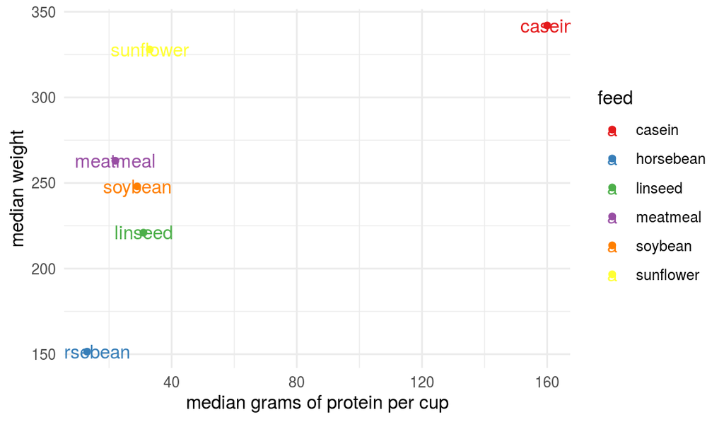

```r
#pipe the dataset
total_data_6.3 %>%

  #making a plot with label axis and filling in the color with feed
  ggplot(aes(x=median_g_protein, y=median_weight, color=feed))+

  #scatterplot and adding text and label be feed
  geom_point() + geom_text(aes(label=feed)) +

  #clearing up the axis
  labs(x="median grams of protein per cup", y="median weight") +

  #changing the color
  scale_color_brewer(palette = "Set1")
```

Now, feel disappointed in the viz and feel thrilled to learn about the library [`ggrepel`](https://cran.r-project.org/web/packages/ggrepel/vignettes/ggrepel.html). (GO OVER THE POST! GO OVER THE POST! The word ggrepel back there is a LINK!) Load this library in the setup chunk (not here!), and use it below to make an updated version of the figure but instead of `geom_text()`, use EITHER `geom_text_repel()` or `geom_label_repel()` - your choice! Ensure a compelling and attractive figure (to the extent possible with this data..)

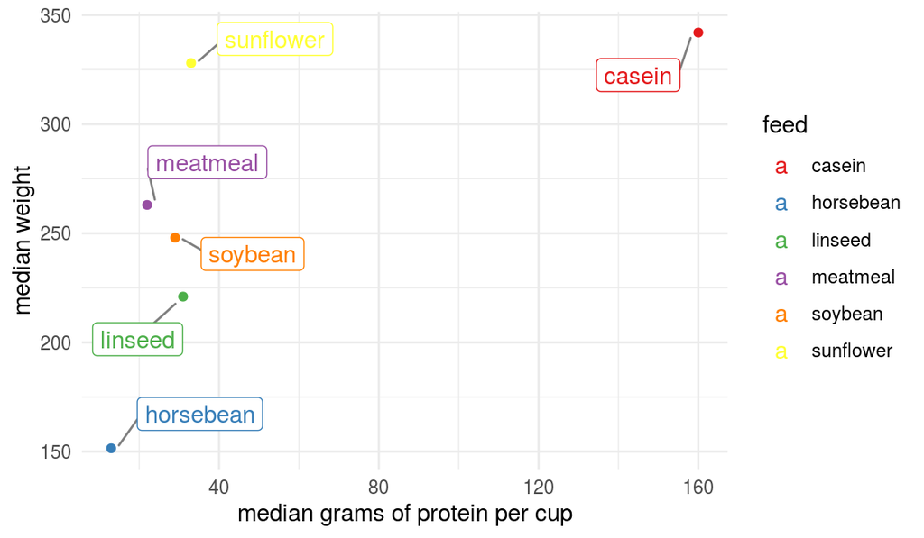

```r
###fig using ggrepel

#pipe the dataset
total_data_6.3 %>%

  #making a plot with label axis and filling in the color with feed
  ggplot(aes(x=median_g_protein,
             y=median_weight,
             color=feed))+

  #scatterplot and adding text and label be feed
  geom_point() +

  #fixing the labels on the graph. The label by feed
    geom_label_repel(aes(label = feed),
                  #placing box around the label
                  box.padding   = 0.35,
                  #adding lines to the box
                  point.padding = 0.5,
                  #the grey line to the point to the label
                  segment.color = "grey50") +

  #clearing up the axis
  labs(x="median grams of protein per cup",
       y="median weight") +

  #changing the color
  scale_color_brewer(palette = "Set1")
```